# Homework 03

## Question 1: Build an `explain-to-me` skill

Create a small skill named `explain-to-me` that helps you understand a homework question.

1. Design your `SKILL.md` file so that, when you explicitly ask your agent to use the skill to read a homework question, the agent communicates with you and explains what the question is asking.
2. Keep the skill file short. It should contain a few useful rules, instructions, and a clear statement of your intent. For example, you may ask the agent to explain the goal of the question, clarify what work is required, and point you to an appropriate section of the Week 3 lectures: [Ridge Regression: Stability Through Shrinkage](https://teazrq.github.io/stat432rpy/topics/ridge-regression/ridge-regression.html) or [From a Penalized Objective to a Fitted Ridge Model](https://teazrq.github.io/stat432rpy/topics/ridge-regression/optimization-and-cross-validation.html). The skill should help you understand the question without completing the solution for you.
3. Create the skill yourself or with the help of AI. Save it as `explain-to-me/SKILL.md`. Then ask your AI agent to install the skill using its normal skill-installation method. Test it by explicitly asking the agent to use `explain-to-me` to read and explain Question 2.
4. If the skill does not work well, or if it begins to disturb your usual workflow, ask your agent to remove the installed skill. You may revise and reinstall it if you wish.
5. In all cases, append the complete contents of your developed `explain-to-me/SKILL.md` file at the end of your Homework 3 submission under the heading **`explain-to-me` skill**.

## Question 2: Ridge regression with nearly collinear predictors

Let $n=100$. Generate mutually independent standard normal random variables

$$L_i, U_{i1}, U_{i2}, X_{i3}, X_{i4},
\qquad i=1,\ldots,n,$$

and define

$$X_{i1}=L_i+0.04U_{i1},
\qquad
X_{i2}=L_i+0.04U_{i2}.$$

Center and standardize each column of $\mathbf X$ to have mean zero and average squared value one, following the [lecture’s scaling convention](https://teazrq.github.io/stat432rpy/topics/ridge-regression/ridge-regression.html#put-every-covariate-on-a-common-scale).

Continue to use $\mathbf X\in\mathbb R^{n\times p}$ for the standardized matrix and keep it fixed throughout the question, where $p=4$ is the number of predictors. The unpenalized intercept gives $p+1=5$ total fitted coefficients. Let

$$\boldsymbol\beta
=
(1.5,1.5,1,0)^{\mathsf T},
\qquad
\boldsymbol\mu
=
\mathbf X\boldsymbol\beta.$$

Generate a training response and an independent test response at the same predictor values:

$$\begin{aligned}
\mathbf y
&=
\boldsymbol\mu+\boldsymbol\epsilon,\\
\mathbf y^*
&=
\boldsymbol\mu+\boldsymbol\epsilon^*,
\end{aligned}$$

where

$$\boldsymbol\epsilon,
\boldsymbol\epsilon^*
\overset{\mathrm{ind}}{\sim}
\mathcal N_n(\mathbf0,\mathbf I_n).$$

Center the training response as $\widetilde{\mathbf y}=\mathbf y-\bar y\mathbf1_n$. For each $\lambda\in\{0,0.02,0.2\}$, fit the slopes using the lecture’s ridge formula:

$$\widehat{\boldsymbol\beta}_\lambda
=
\left(\mathbf X^{\mathsf T}\mathbf X+n\lambda\mathbf I_p\right)^{-1}
\mathbf X^{\mathsf T}\widetilde{\mathbf y}.$$

The unpenalized intercept is $\widehat\beta_0=\bar y$; add this training mean back when predicting either response. The case $\lambda=0$ is ordinary least squares. Use seed `43231` before generating the design and responses. R and Python use different random-number generators, so their exact numerical results need not agree.

1. Generate $\mathbf X$ once. Report the correlation between its first two columns and its largest and smallest singular values. Use these quantities to explain why the estimator contrast $\widehat\beta_1-\widehat\beta_2$ should be much more variable than $\widehat\beta_1+\widehat\beta_2$.

**Show the workflow**

```r
set.seed(43231)
n <- 100

L <- rnorm(n)
U1 <- rnorm(n)
U2 <- rnorm(n)
X3 <- rnorm(n)
X4 <- rnorm(n)

X <- cbind(L + 0.04 * U1, L + 0.04 * U2, X3, X4)

for (j in 1:4) {
  X[, j] <- X[, j] - mean(X[, j])
  X[, j] <- X[, j] / sqrt(mean(X[, j]^2))
}

d <- svd(X)$d

c(
  correlation = cor(X[, 1], X[, 2]),
  largest = max(d),
  smallest = min(d)
)
```

```
correlation     largest    smallest
  0.9977057  14.1414804   0.4753575
```

The correlation is approximately 0.9977, and the largest and smallest singular values are 14.1415 and 0.4754, indicating near-collinearity. Increasing one coefficient while equally decreasing the other barely changes the fitted values. Thus, the data provide less information about the coefficient difference than the sum, making $\hat{\beta}_1-\hat{\beta}_2$ much more variable than $\hat{\beta}_1+\hat{\beta}_2$ under ordinary least squares.

2. Independently repeat the generation of $\mathbf y$ and $\mathbf y^*$, followed by all three fits, 200 times while keeping $\mathbf X$ fixed. Draw the training and test noise inside each repetition, then reuse that realized pair for all three values of $\lambda$. For each value of $\lambda$, report the empirical mean and standard deviation of

$$\widehat\beta_1,
\quad
\widehat\beta_2,
\quad
\widehat\beta_1+\widehat\beta_2,
\quad
\widehat\beta_1-\widehat\beta_2.$$

Also report the average training MSE and the average test MSE calculated from the independent test response, where

$$\operatorname{MSE}_{\mathrm{test}}
=
\frac{1}{n}
\left\lVert
\mathbf y^*
-
\widehat\beta_0\mathbf1_n
-
\mathbf X\widehat{\boldsymbol\beta}
\right\rVert_2^2.$$

**Show the workflow**

```r
n <- nrow(X)
p <- ncol(X)
mu <- as.vector(X %*% c(1.5, 1.5, 1, 0))

results <- data.frame()

for (i in 1:200) {
  y <- mu + rnorm(n)
  y_test <- mu + rnorm(n)
  y_bar <- mean(y)

  for (lam in c(0, 0.02, 0.2)) {
    b <- solve(t(X) %*% X + n * lam * diag(p),
               t(X) %*% (y - y_bar))

    pred <- as.vector(y_bar + X %*% b)

    results <- rbind(results, data.frame(
      lambda = lam,
      beta1 = b[1],
      beta2 = b[2],
      sum12 = b[1] + b[2],
      diff12 = b[1] - b[2],
      train_MSE = mean((y - pred)^2),
      test_MSE = mean((y_test - pred)^2)
    ))
  }
}

mean_results <- aggregate(. ~ lambda, data = results, FUN = mean)
round(mean_results, 4)
```

```
  lambda  beta1  beta2  sum12  diff12 train_MSE test_MSE
1   0.00 1.4956 1.5098 3.0054 -0.0142    0.9648   1.0625
2   0.02 1.4870 1.4892 2.9762 -0.0022    0.9747   1.0493
3   0.20 1.3679 1.3687 2.7366 -0.0008    1.0768   1.1335
```

**Show the workflow**

```r
sd_results <- aggregate(. ~ lambda,
                        data = results[, 1:5], FUN = sd)
round(sd_results, 4)
```

```
  lambda  beta1  beta2  sum12 diff12
1   0.00 1.5439 1.5486 0.0951 3.0911
2   0.02 0.1615 0.1659 0.0942 0.3136
3   0.20 0.0457 0.0473 0.0865 0.0344
```

3. Interpret the coefficient estimates and test MSE using bias and variance. Explain why ridge can substantially stabilize the individual coefficients without producing an equally large change in the fitted values.

OLS is unbiased, but its individual coefficient estimates have high variance because the first two predictors are nearly identical. Ridge reduces this variance by shrinking the coefficients, at the cost of some bias. A moderate penalty can lower test MSE, while too much shrinkage can increase it. Predictions depend mainly on $\hat{\beta}_1+\hat{\beta}_2$, so opposite changes in the two coefficients largely cancel out. Ridge strongly reduces variation in $\hat{\beta}_1-\hat{\beta}_2$, making the individual coefficients more stable without changing the fitted values as much.

## Question 3: What does ridge regression shrink?

Let $\mathbf X\in\mathbb R^{n\times p}$ be a centered predictor matrix, and let $\widetilde{\mathbf y}\in\mathbb R^n$ be the centered response. Use the supplied predictor scales for this algebraic question; the columns need not have unit variance. Here $p$ counts predictors, $\boldsymbol\beta\in\mathbb R^p$ contains their slopes, and $p+1$ counts all fitted coefficients, including the separately fitted, unpenalized intercept. Ridge regression minimizes

$$L_\lambda(\boldsymbol\beta)
=
\frac{1}{2n}
\left\lVert
\widetilde{\mathbf y}-\mathbf X\boldsymbol\beta
\right\rVert_2^2
+
\frac{\lambda}{2}
\lVert\boldsymbol\beta\rVert_2^2.$$

1. Derive the ridge normal equation

$$\left(
\mathbf X^{\mathsf T}\mathbf X
+n\lambda\mathbf I_p
\right)
\widehat{\boldsymbol\beta}_\lambda
=
\mathbf X^{\mathsf T}\widetilde{\mathbf y}.$$

Explain why it has a unique solution whenever $\lambda>0$, even if $\mathbf X$ is rank deficient or $p>n$.

Taking the gradient with respect to $\beta$ gives

$$\nabla_\beta L_\lambda(\beta)
= -\frac{1}{n}X^\top(\widetilde{y}-X\beta)+\lambda\beta.$$

Setting the gradient equal to zero and rearranging gives the ridge normal equation:

$$(X^\top X+n\lambda I_p)\hat{\beta}_\lambda
= X^\top\widetilde{y}.$$

For any nonzero vector $v$ and $\lambda>0$,

$$v^\top(X^\top X+n\lambda I_p)v
= \|Xv\|_2^2+n\lambda\|v\|_2^2>0.$$

Thus, $X^\top X+n\lambda I_p$ is positive definite and invertible. The loss is strictly convex, so the unique minimizer is

$$\hat{\beta}_\lambda
= (X^\top X+n\lambda I_p)^{-1}X^\top\widetilde{y}.$$

This remains true even when $X$ is rank deficient or $p>n$, because the penalty adds a strictly positive term in every coefficient direction.

2. Let

$$\mathbf X
=
\mathbf U_r\mathbf D_r\mathbf V_r^{\mathsf T}$$

be a compact singular value decomposition, where $r=\operatorname{rank}(\mathbf X)$, $\mathbf U_r\in\mathbb R^{n\times r}$, $\mathbf D_r\in\mathbb R^{r\times r}$, and $\mathbf V_r\in\mathbb R^{p\times r}$. Show that ridge multiplies the fitted response component in the $j$th left singular-vector direction, for $j=1,\ldots,r$, by

$$\rho_j(\lambda)
=
\frac{d_j^2}{d_j^2+n\lambda}.$$

Suppose $n=100$, $\lambda=0.01$, and the nonzero singular values are

$$d_1=10,
\qquad
d_2=2,
\qquad
d_3=0.2.$$

Calculate the three shrinkage factors and the total effective degrees of freedom, including the unpenalized intercept:

$$\operatorname{df}_{\mathrm{eff}}(\lambda)
=
1+\sum_{j=1}^3\rho_j(\lambda).$$

Using $X=U_rD_rV_r^\top$, the centered fitted response is

$$\begin{aligned}
X\hat{\beta}_\lambda
&= X(X^\top X+n\lambda I_p)^{-1}X^\top\widetilde{y}\\
&= U_rD_r(D_r^2+n\lambda I_r)^{-1}D_rU_r^\top\widetilde{y}\\
&= \sum_{j=1}^{r}
\frac{d_j^2}{d_j^2+n\lambda}
u_j(u_j^\top\widetilde{y}),
\end{aligned}$$

where $u_j$ is the $j$th column of $U_r$. The OLS fitted response is $\sum_{j=1}^{r}u_j(u_j^\top\widetilde{y})$, so ridge multiplies each component by

$$\rho_j(\lambda)=\frac{d_j^2}{d_j^2+n\lambda}.$$

Since $n\lambda=100(0.01)=1$, the three shrinkage factors are

$$\begin{aligned}
\rho_1 &= \frac{10^2}{10^2+1}
= \frac{100}{101}\approx 0.9901,\\
\rho_2 &= \frac{2^2}{2^2+1}
= \frac{4}{5}=0.8000,\\
\rho_3 &= \frac{0.2^2}{0.2^2+1}
= \frac{0.04}{1.04}\approx 0.0385.
\end{aligned}$$

Including the unpenalized intercept, the total effective degrees of freedom are

$$\mathrm{df}_{\mathrm{eff}}(\lambda)
=1+\frac{100}{101}+\frac{4}{5}+\frac{0.04}{1.04}
\approx 2.8286.$$

The additional $1$ accounts for the intercept, which is not penalized.

3. Which direction receives the strongest shrinkage? Explain why shrinking this direction can reduce prediction variance. Under what circumstance could the same shrinkage produce substantial prediction bias?

The third left singular-vector direction, $u_3$, receives the strongest shrinkage because $d_3=0.2$ is the smallest singular value and $\rho_3\approx0.0385$. Ridge keeps only about 3.85% of the fitted component in this direction. This also reduces the noise contribution, multiplying its variance by $\rho_3^2$ relative to OLS. However, if the true mean response has a large component along $u_3$, this strong shrinkage removes important signal as well as noise, causing substantial prediction bias.

## Question 4: Ridge regression and optimization

Let $\mathbf X\in\mathbb R^{n\times p}$ be a centered predictor matrix with $p=2$. Its columns need not have unit variance in this question. The intercept is fitted separately and is not penalized. Suppose the two eigenvalues of

$$\mathbf A_0
=
\frac{1}{n}\mathbf X^{\mathsf T}\mathbf X$$

are $9$ and $0.01$. Ridge regression with $\lambda=0.09$ has curvature matrix

$$\mathbf A_\lambda
=
\frac{1}{n}\mathbf X^{\mathsf T}\mathbf X
+
\lambda\mathbf I_p.$$

1. Calculate the condition numbers of $\mathbf A_0$ and $\mathbf A_\lambda$. Explain what the change says about the geometry of the ridge objective.

The condition number of $A_0$ is

$$\kappa(A_0)=\frac{9}{0.01}=900.$$

Ridge adds $\lambda=0.09$ to each eigenvalue, giving $9.09$ and $0.10$. Therefore,

$$\kappa(A_\lambda)
=\frac{9+0.09}{0.01+0.09}
=\frac{9.09}{0.10}=90.9.$$

The smaller condition number means the ridge objective has less elongated elliptical contours and more balanced curvature across directions. Ridge increases curvature in the nearly flat direction, making the optimization problem better conditioned.

2. Gradient descent uses

$$\boldsymbol\beta^{(k+1)}
=
\boldsymbol\beta^{(k)}
-
\eta\nabla L_\lambda\!\left(\boldsymbol\beta^{(k)}\right).$$

Let $\widehat{\boldsymbol\beta}_\lambda$ be the ridge minimizer and define the optimization error

$$\mathbf e^{(k)}
=
\boldsymbol\beta^{(k)}
-
\widehat{\boldsymbol\beta}_\lambda.$$

Show that the component of $\mathbf e^{(k)}$ in an eigendirection with unpenalized eigenvalue $a$ is multiplied at each step by

$$1-\eta(a+\lambda).$$

Let $M=9.09$, the largest eigenvalue of $\mathbf A_\lambda$. Find the interval of step sizes that contracts every eigendirection. Then compare these two choices:

- For $\eta=1/M$, calculate the two contraction factors and explain which direction converges faster.
- For $\eta=2.1/M$, determine whether the method converges. Assume the initial error has a nonzero component in the eigendirection corresponding to $M$.

The gradient is

$$\nabla L_\lambda(\beta)
=A_\lambda\beta-\frac{1}{n}X^\top\widetilde{y}.$$

Since the gradient is zero at $\hat{\beta}_\lambda$, the optimization error satisfies

$$\begin{aligned}
e^{(k+1)}
&=\beta^{(k+1)}-\hat{\beta}_\lambda\\
&=(I_p-\eta A_\lambda)e^{(k)}.
\end{aligned}$$

If $v$ is an eigenvector of $A_0$ with eigenvalue $a$, then $A_\lambda v=(a+\lambda)v$. Therefore,

$$v^\top e^{(k+1)}
=[1-\eta(a+\lambda)]v^\top e^{(k)}.$$

Thus, the error component in this direction is multiplied by $1-\eta(a+\lambda)$ at each step.

Every direction contracts when $|1-\eta(a+\lambda)|<1$. Using the largest eigenvalue $M=9.09$, the required interval is

$$0<\eta<\frac{2}{M}
=\frac{2}{9.09}\approx0.2200.$$

For $\eta=1/M$, the two contraction factors are

$$\begin{aligned}
1-\eta(9.09)&=0,\\
1-\eta(0.10)&=1-\frac{0.10}{9.09}\approx0.9890.
\end{aligned}$$

The direction with eigenvalue $9.09$ converges faster: its error becomes zero after one step. The direction with eigenvalue $0.10$ converges slowly because its factor is close to one.

For $\eta=2.1/M$, the two error multipliers are

$$\begin{aligned}
1-\eta(9.09)&=1-2.1=-1.1,\\
1-\eta(0.10)&=1-\frac{2.1(0.10)}{9.09}\approx0.9769.
\end{aligned}$$

The first multiplier has absolute value greater than one, so that error component alternates in sign and grows by 10% each step. Since the initial error has a nonzero component in this direction, the method diverges.

3. Increasing $\lambda$ generally improves the condition number. Explain why choosing $\lambda$ to make gradient descent converge as quickly as possible is not a valid statistical tuning rule.

A larger $\lambda$ improves conditioning, but it also changes the fitted model by shrinking the coefficients more strongly. Choosing $\lambda$ only for fast convergence can remove useful signal, increase bias, and worsen prediction. As $\lambda\to\infty$, the condition number approaches one, but the slopes approach zero, so the model predicts only the training mean. Therefore, fast optimization does not guarantee good statistical performance. The penalty should be selected using prediction-based criteria, such as cross-validation or GCV, rather than convergence speed.

## Question 5: Selecting the ridge penalty for real-estate prediction

The supplied `data/realestate.csv` contains 414 real-estate transactions from Sindian District, New Taipei City, Taiwan. The quantitative response `price` is the unit house price. The six predictors are the transaction date, house age, distance to the nearest mass rapid transit station, number of nearby convenience stores, latitude, and longitude. Treat all six predictors as quantitative in this question. The column `row_id` identifies an observation and must not be used as a predictor.

The file `data/realestate-split-folds.csv` assigns 332 observations to the training set and 82 observations to the final test set. It also gives ten fold labels for the training observations. Match the two files using `row_id` and do not use the test responses while selecting a model.

Use the penalty grid

$$\Lambda
=
\{0\}
\mathbin{\cup}
\left\{
10^{-4+0.05l}:l=0,\ldots,120
\right\}.$$

For every fit, center and standardize each predictor using only the observations available to that fit, with the variance divided by the number of fitting observations. Center the response and leave the intercept unpenalized.

1. Perform ten-fold cross-validation over $\Lambda$ using the supplied training folds. Estimate the predictor means and scales separately within each set of nine training folds. For each $\lambda$, calculate the mean validation MSE and $\operatorname{SE}(\lambda)$, the sample standard deviation of the ten fold errors divided by $\sqrt{10}$. Use this SE for the conventional one-standard-error heuristic. Plot the mean validation MSE and identify $\lambda_{\min}$. Choose $\lambda_{\mathrm{1se}}$ as the largest candidate in $\Lambda$, including OLS, satisfying

$$\overline{\operatorname{MSE}}(\lambda)
\leq
\overline{\operatorname{MSE}}(\lambda_{\min})
+
\operatorname{SE}(\lambda_{\min}).$$

**Show the workflow**

```r
dat <- read.csv("data/realestate.csv")
folds <- read.csv("data/realestate-split-folds.csv")

xvars <- setdiff(names(dat), c("row_id", "price"))

train <- merge(dat, folds, by = "row_id")
train <- train[train$split == "train", ]

X_train <- as.matrix(train[, xvars])
y_train <- train$price
fold_id <- train$cv_fold
```

**Show the workflow**

```r
lambda <- c(0, 10^(-4 + 0.05 * (0:120)))
fold_mse <- matrix(NA, 10, length(lambda))
fold_values <- sort(unique(fold_id))

for (k in 1:10) {
  fit <- fold_id != fold_values[k]

  X_fit <- X_train[fit, ]
  X_valid <- X_train[!fit, ]
  y_fit <- y_train[fit]

  for (j in 1:ncol(X_fit)) {
    m <- mean(X_fit[, j])
    s <- sqrt(mean((X_fit[, j] - m)^2))

    X_fit[, j] <- (X_fit[, j] - m) / s
    X_valid[, j] <- (X_valid[, j] - m) / s
  }

  for (j in seq_along(lambda)) {
    b <- solve(
      t(X_fit) %*% X_fit + nrow(X_fit) * lambda[j] * diag(ncol(X_fit)),
      t(X_fit) %*% (y_fit - mean(y_fit))
    )

    pred <- mean(y_fit) + X_valid %*% b
    fold_mse[k, j] <- mean((y_train[!fit] - pred)^2)
  }
}
```

**Show the workflow**

```r
cv_mean <- colMeans(fold_mse)
cv_se <- apply(fold_mse, 2, sd) / sqrt(10)

i_min <- which.min(cv_mean)
cutoff <- cv_mean[i_min] + cv_se[i_min]
i_1se <- max(which(cv_mean <= cutoff))

lambda_min <- lambda[i_min]
lambda_1se <- lambda[i_1se]

data.frame(
  choice = c("lambda_min", "lambda_1se"),
  lambda = c(lambda_min, lambda_1se),
  MSE = cv_mean[c(i_min, i_1se)],
  SE = cv_se[c(i_min, i_1se)]
)
```

```
      choice     lambda       MSE       SE
1 lambda_min 0.01995262  82.97765 19.22991
2 lambda_1se 1.58489319 101.59553 19.97678
```

**Show the workflow**

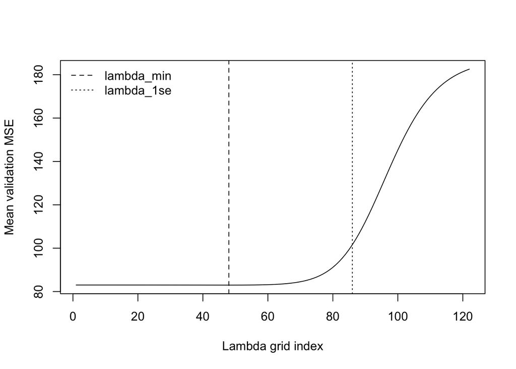

```r
plot(cv_mean, type = "l",
     xlab = "Lambda grid index",
     ylab = "Mean validation MSE")

abline(v = i_min, lty = 2)
abline(v = i_1se, lty = 3)

legend("topleft",
       legend = c("lambda_min", "lambda_1se"),
       lty = c(2, 3), bty = "n")
```

2. Use all $n=332$ training observations to calculate the [lecture’s GCV criterion](https://teazrq.github.io/stat432rpy/topics/ridge-regression/optimization-and-cross-validation.html#loocv-and-gcv) for each $\lambda\in\Lambda$:

$$\operatorname{GCV}(\lambda)
=
\frac{
\operatorname{MSE}_{\mathrm{train}}(\lambda)
}{
\left\{
1-\operatorname{df}_{\mathrm{eff}}(\lambda)/n
\right\}^2
}.$$

Here $\operatorname{MSE}_{\mathrm{train}}$ is the training MSE, and $\operatorname{df}_{\mathrm{eff}}$ includes the unpenalized intercept, as in Question 3. Estimate means and scales once from all training observations and keep them fixed for this calculation. Plot the GCV curve and identify $\lambda_{\mathrm{GCV}}$.

**Show the workflow**

```r
Z <- X_train
n <- nrow(Z)
p <- ncol(Z)
y_mean <- mean(y_train)

for (j in 1:p) {
  Z[, j] <- Z[, j] - mean(Z[, j])
  Z[, j] <- Z[, j] / sqrt(mean(Z[, j]^2))
}

d <- svd(Z)$d
```

**Show the workflow**

```r
gcv <- numeric(length(lambda))

for (j in seq_along(lambda)) {
  b <- solve(
    t(Z) %*% Z + n * lambda[j] * diag(p),
    t(Z) %*% (y_train - y_mean)
  )

  pred <- y_mean + Z %*% b
  mse <- mean((y_train - pred)^2)

  df_eff <- 1 + sum(d^2 / (d^2 + n * lambda[j]))
  gcv[j] <- mse / (1 - df_eff / n)^2
}
```

**Show the workflow**

```r
i_gcv <- which.min(gcv)
lambda_gcv <- lambda[i_gcv]

data.frame(
  lambda_GCV = lambda_gcv,
  GCV = gcv[i_gcv]
)
```

```
  lambda_GCV      GCV
1 0.02818383 83.50191
```

**Show the workflow**

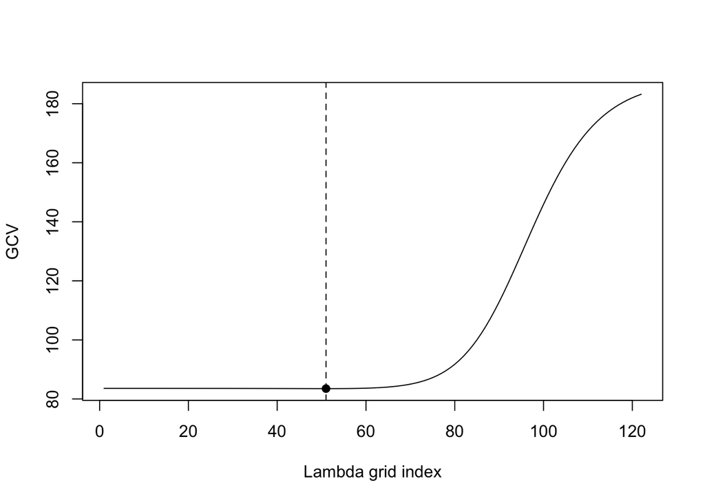

```r
# Plot the GCV curve
plot(gcv, type = "l",
     xlab = "Lambda grid index",
     ylab = "GCV")

abline(v = i_gcv, lty = 2)
points(i_gcv, gcv[i_gcv], pch = 19)
```

3. Fix all three choices before examining the test responses. Refit OLS and ridge at $\lambda_{\min}$, $\lambda_{\mathrm{1se}}$, and $\lambda_{\mathrm{GCV}}$ using all training observations. Report each model’s training MSE, test MSE, and effective degrees of freedom. Interpret the differences and explain why the model with the smallest observed test MSE must not be selected after viewing this table.

**Show the workflow**

```r
penalties <- c(0, lambda_min, lambda_1se, lambda_gcv)

test <- merge(dat, folds, by = "row_id")
test <- test[test$split == "test", ]

Z_test <- as.matrix(test[, xvars])
y_test <- test$price

for (j in 1:p) {
  m <- mean(X_train[, j])
  s <- sqrt(mean((X_train[, j] - m)^2))
  Z_test[, j] <- (Z_test[, j] - m) / s
}
```

**Show the workflow**

```r
comparison <- data.frame(
  model = c("OLS", "Ridge_min", "Ridge_1se", "Ridge_GCV"),
  lambda = penalties,
  train_MSE = NA,
  test_MSE = NA,
  df_eff = NA
)

for (j in 1:4) {
  b <- solve(
    t(Z) %*% Z + n * penalties[j] * diag(p),
    t(Z) %*% (y_train - y_mean)
  )

  pred_train <- y_mean + Z %*% b
  pred_test <- y_mean + Z_test %*% b

  comparison$train_MSE[j] <- mean((y_train - pred_train)^2)
  comparison$test_MSE[j] <- mean((y_test - pred_test)^2)
  comparison$df_eff[j] <- 1 + sum(d^2 / (d^2 + n * penalties[j]))
}

print(comparison, digits = 4, row.names = FALSE)
```

```
     model  lambda train_MSE test_MSE df_eff
       OLS 0.00000     80.09    66.32  7.000
 Ridge_min 0.01995     80.14    66.00  6.773
 Ridge_1se 1.58489    100.37    81.20  3.033
 Ridge_GCV 0.02818     80.17    65.90  6.689
```

OLS has the lowest training MSE because it minimizes training squared error. Larger penalties reduce effective degrees of freedom but increase training MSE. Ridge may improve prediction by reducing variance, although excessive shrinkage can introduce too much bias. The smallest observed test MSE does not guarantee the best performance on future data. Choosing a model after comparing test MSEs would use the test set for tuning and could make the reported performance overly optimistic. The model choices must therefore remain fixed before examining the test results.

**TipStarter workflow**

After matching the two files by `row_id`, use this order:

```
for each validation fold:
    estimate predictor means and scales from the other nine folds
    for each lambda:
        fit on those nine folds and record validation MSE
summarize the ten fold errors and fix lambda_min and lambda_1se
compute GCV using all training observations and fix lambda_GCV
only then refit the four reported models and evaluate the test responses
```

## Reference

The real-estate data come from I-Cheng Yeh’s [Real Estate Valuation dataset](https://archive.ics.uci.edu/dataset/477/real%2Bestate%2Bvaluation%2Bda) in the UCI Machine Learning Repository. The distributed data retain the original observations and add only the course train-test and fold assignments.

## `explain-to-me` skill

```markdown
---
name: explain-to-me
description: Help the user understand a homework question without solving it.
---

# Explain to Me

Use this skill only when the user explicitly asks to use `explain-to-me`.

## Instructions

1. Read the requested homework question. If it is missing, ask the user to provide it.
2. Explain the main goal in simple English.
3. Identify the given information and explain important terms or symbols.
4. Break the question into small tasks and explain what the user needs to submit.
5. When helpful, point to a relevant section of the Week 3 lectures listed below.
6. Ask the user which part needs more explanation.

## Limits

Help the user understand the question without completing the solution for them.
Do not provide final answers or solution code.

## Week 3 Lectures

- [Ridge Regression: Stability Through Shrinkage](https://teazrq.github.io/stat432rpy/topics/ridge-regression/ridge-regression.html)
- [From a Penalized Objective to a Fitted Ridge Model](https://teazrq.github.io/stat432rpy/topics/ridge-regression/optimization-and-cross-validation.html)
```